# Market Basket Analysis

# Libraries

```r
library(tidyverse)
library(knitr)
library(kableExtra)
library(corrplot)
library(reshape2)
library(Amelia)
library(dlookr)
library(fpp2)
library(plotly)
library(gridExtra)
library(readxl)
library(ggplot2)
library(urca)
library(tseries)
library(AppliedPredictiveModeling)
library(RANN)
library(psych)
library(e1071)
library(corrplot)
library(glmnet)
library(mlbench)
library(caret)
library(earth)
library(randomForest)
library(party)
library(Cubist)
library(gbm)
library(rpart)
library(dplyr)
library(arulesViz)
library(igraph)
```

# Problem statement

Imagine 10000 receipts sitting on your table. Each receipt represents a transaction with items that were purchased. The receipt is a representation of stuff that went into a customer’s basket - and therefore “Market Basket Analysis”.

That is exactly what the Groceries Data Set contains: a collection of receipts with each line representing 1 receipt and the items purchased. Each line is called a transaction and each column in a row represents an item. The data set is attached.

Your assignment is to use R to mine the data for association rules. You should report support, confidence and lift and your top 10 rules by lift.

Extra credit: do a simple cluster analysis on the data as well. Use whichever packages you like. Due May 3 before midnight.

# Brief explanation

Initially, I proceeded to read with read_csv. Although I was able to read the usual csv file (GroceryDataSet.csv i.e.), it didn’t help in down stream analysis. So, in order to mine the data for **Association Rules**, I googled and learned that apriori() function was required. This is not something, which we customarily use or have used so in the past. On googling, I hit upon the following page:

```
https://blog.aptitive.com/building-the-transactions-class-for-association-rule-mining-in-r-using-arules-and-apriori-c6be64268bc4
```

The page gives an overview of transactions class, apriori() functions etc. The package arules is required, which I added to the list of libraries above. “Market Basket Analysis” was a good clue.  
Explanation of some of the terms in Association Rules, which we’ll encounter below:

Support of a set of items is the frequency with which, an item appears in the dataset.

Confidence of a rule is the frequency of how often a rule has been found to be true.

Lift is the ratio of the actual support to the expected support.

# Reading data and summary

```r
# grocery_transactions <- read_csv('./GroceryDataSet.csv')
grocery_transactions <- read.transactions('./GroceryDataSet.csv', sep = ",")
```

```r
summary(grocery_transactions)
```

```
## transactions as itemMatrix in sparse format with
##  9835 rows (elements/itemsets/transactions) and
##  169 columns (items) and a density of 0.02609146
##
## most frequent items:
##       whole milk other vegetables       rolls/buns             soda
##             2513             1903             1809             1715
##           yogurt          (Other)
##             1372            34055
##
## element (itemset/transaction) length distribution:
## sizes
##    1    2    3    4    5    6    7    8    9   10   11   12   13   14   15   16
## 2159 1643 1299 1005  855  645  545  438  350  246  182  117   78   77   55   46
##   17   18   19   20   21   22   23   24   26   27   28   29   32
##   29   14   14    9   11    4    6    1    1    1    1    3    1
##
##    Min. 1st Qu.  Median    Mean 3rd Qu.    Max.
##   1.000   2.000   3.000   4.409   6.000  32.000
##
## includes extended item information - examples:
##             labels
## 1 abrasive cleaner
## 2 artif. sweetener
## 3   baby cosmetics
```

From summary, we see that some of the most freuent items are “whole milk”, “other vegetables”, “rolls/buns”, “soda” etc. In order to get a better visualization, I’ll use function itemFrequencyPlot().

# Frequency of top 20 most frequent items

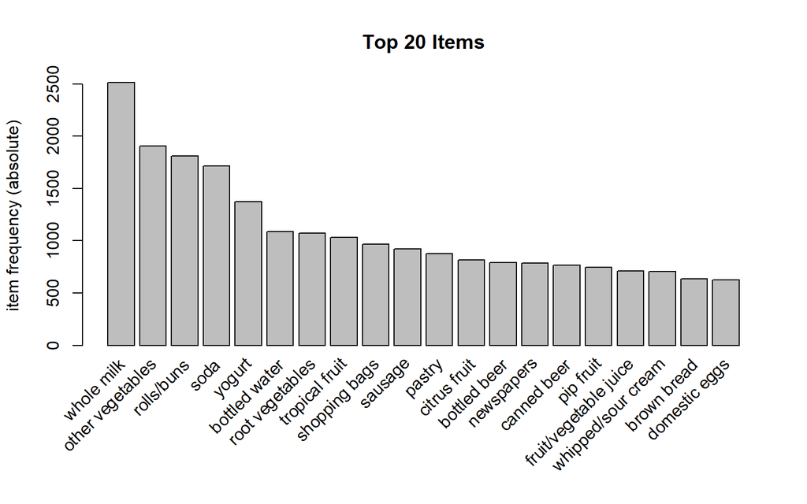

```r
itemFrequencyPlot(grocery_transactions, topN = 20, type = "absolute", main = "Top 20 Items")
```

This graph gives an idea of frequencies of top 20 most frequent items. This graph corroborate the few observations in summary.

# Further analysis

```r
support <- 0.001
confidence <- 0.4
rules <- apriori(grocery_transactions, parameter = list(support = support, confidence = confidence), control = list(verbose = FALSE))
```

```r
summary(rules)
```

```
## set of 8955 rules
##
## rule length distribution (lhs + rhs):sizes
##    2    3    4    5    6
##   81 2771 4804 1245   54
##
##    Min. 1st Qu.  Median    Mean 3rd Qu.    Max.
##   2.000   3.000   4.000   3.824   4.000   6.000
##
## summary of quality measures:
##     support           confidence        coverage             lift
##  Min.   :0.001017   Min.   :0.4000   Min.   :0.001017   Min.   : 1.565
##  1st Qu.:0.001118   1st Qu.:0.4583   1st Qu.:0.001932   1st Qu.: 2.316
##  Median :0.001322   Median :0.5319   Median :0.002542   Median : 2.870
##  Mean   :0.001811   Mean   :0.5579   Mean   :0.003478   Mean   : 3.191
##  3rd Qu.:0.001830   3rd Qu.:0.6296   3rd Qu.:0.003559   3rd Qu.: 3.733
##  Max.   :0.056024   Max.   :1.0000   Max.   :0.139502   Max.   :21.494
##      count
##  Min.   : 10.00
##  1st Qu.: 11.00
##  Median : 13.00
##  Mean   : 17.81
##  3rd Qu.: 18.00
##  Max.   :551.00
##
## mining info:
##                  data ntransactions support confidence
##  grocery_transactions          9835   0.001        0.4
```

An important observation in summary is, there 8955 rules with length from 2 to 6.

```r
rules %>% DATAFRAME() %>% arrange(desc(lift)) %>% top_n(10) %>% kable()
```

| LHS | RHS | support | confidence | coverage | lift | count |
| --- | --- | --- | --- | --- | --- | --- |
| {root vegetables} | {other vegetables} | 0.0473818 | 0.4347015 | 0.1089985 | 2.246605 | 466 |
| {whipped/sour cream} | {other vegetables} | 0.0288765 | 0.4028369 | 0.0716828 | 2.081924 | 284 |
| {butter} | {whole milk} | 0.0275547 | 0.4972477 | 0.0554143 | 1.946053 | 271 |
| {curd} | {whole milk} | 0.0261312 | 0.4904580 | 0.0532791 | 1.919480 | 257 |
| {domestic eggs} | {whole milk} | 0.0299949 | 0.4727564 | 0.0634469 | 1.850203 | 295 |
| {whipped/sour cream} | {whole milk} | 0.0322318 | 0.4496454 | 0.0716828 | 1.759754 | 317 |
| {root vegetables} | {whole milk} | 0.0489070 | 0.4486940 | 0.1089985 | 1.756031 | 481 |
| {margarine} | {whole milk} | 0.0241993 | 0.4131944 | 0.0585663 | 1.617098 | 238 |
| {tropical fruit} | {whole milk} | 0.0422979 | 0.4031008 | 0.1049314 | 1.577595 | 416 |
| {yogurt} | {whole milk} | 0.0560244 | 0.4016035 | 0.1395018 | 1.571735 | 551 |

The following graph gives a good visualization of how the items are associating.

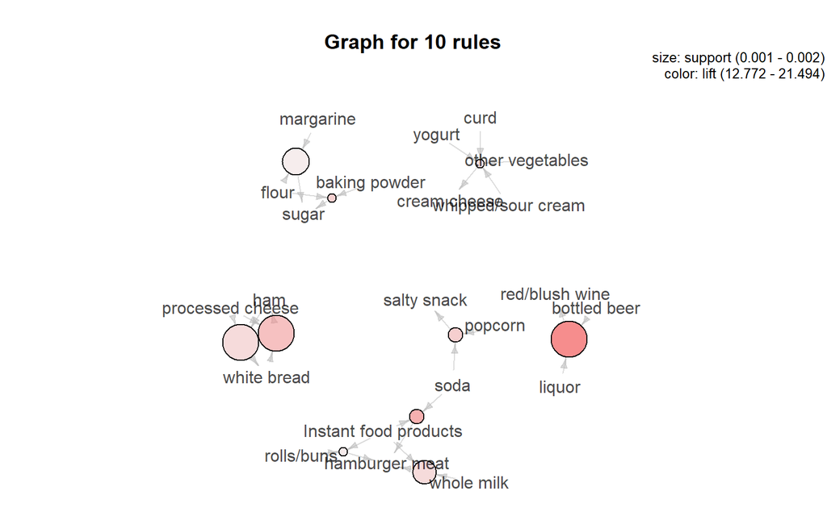

```r
subrules <- head(rules, n = 10, by = 'lift')
plot(subrules, method = 'graph')
```

# Cluster analysis

```r
grocery_csv <- read.csv("GroceryDataSet.csv", header = FALSE) %>% mutate(shoper_id = row_number()) %>% pivot_longer(-shoper_id) %>% filter(value != "") %>% select(-name)

communities <- grocery_csv %>% rename(to = value, from = shoper_id) %>% graph_from_data_frame(directed = FALSE) %>% cluster_louvain() %>% communities()
```

The following step will associate customers and items to 19 clusters.

```r
products <- as.character(unique(grocery_csv$value))

df <- data.frame(name = c(NA), members = c(NA)) %>% na.omit() # create data frame

for (i in 1:length(communities)){
  cluster_name <- paste0(i,": ")
  cluster_members <- 0
  for (member in communities[[i]]){
    if (member %in% products){
      cluster_name <- paste0(cluster_name, member, " + ")
    } else {
      cluster_members <- cluster_members + 1
    }
  }
  cluster_name <- substr(cluster_name,1,nchar(cluster_name)-3)
  df <- rbind(df, data.frame(name = cluster_name, members = cluster_members))
}
  df %>%
  arrange(desc(members)) %>% kable()
```

| name | members |
| --- | --- |
| 8: chocolate + soda + specialty bar + pastry + salty snack + waffles + candy + dessert + chocolate marshmallow + specialty chocolate + popcorn + cake bar + snack products + finished products + make up… | 1292 |
| 10: other vegetables + rice + abrasive cleaner + flour + beef + chicken + root vegetables + bathroom cleaner + spices + pork + turkey + oil + curd cheese + onions + herbs + dog food + frozen fish + sa… | 1087 |
| 12: ready soups + rolls/buns + frankfurter + sausage + spread cheese + hard cheese + canned fish + seasonal products + frozen potato products + sliced cheese + soft cheese + meat + mustard + mayonnais… | 1053 |
| 13: whole milk + butter + cereals + curd + detergent + hamburger meat + flower (seeds) + canned vegetables + pasta + softener + Instant food products + honey + cocoa drinks + cleaner + soups + soap + … | 857 |
| 5: liquor (appetizer) + canned beer + shopping bags + misc. beverages + chewing gum + brandy + liqueur + whisky | 730 |
| 7: yogurt + cream cheese + meat spreads + packaged fruit/vegetables + butter milk + berries + whipped/sour cream + baking powder + specialty cheese + instant coffee + organic sausage + cooking chocola… | 674 |
| 4: tropical fruit + pip fruit + white bread + processed cheese + sweet spreads + beverages + ham + cookware + tea + syrup + baby cosmetics + specialty vegetables + sound storage medium | 624 |
| 15: citrus fruit + hygiene articles + domestic eggs + cat food + cling film/bags + canned fruit + dental care + flower soil/fertilizer + female sanitary products + dish cleaner + house keeping product… | 569 |
| 16: bottled beer + red/blush wine + prosecco + liquor + rum | 432 |
| 11: UHT-milk + bottled water + white wine + male cosmetics | 349 |
| 2: long life bakery product + pot plants + fruit/vegetable juice + pickled vegetables + jam + bags | 341 |
| 3: semi-finished bread + newspapers + pet care + nuts/prunes + toilet cleaner | 298 |
| 6: dishes + napkins + grapes + zwieback + decalcifier | 293 |
| 1: coffee + condensed milk + sparkling wine + fish + kitchen towels | 287 |
| 18: sugar + frozen vegetables + salt + skin care + liver loaf + frozen chicken | 273 |
| 14: frozen dessert + ice cream + frozen meals | 262 |
| 9: margarine + artif. sweetener + specialty fat + candles + organic products | 207 |
| 17: brown bread + sauces | 128 |
| 19: photo/film | 79 |